# Assignment 1

Zhen Lin

1/17/2023

### 1. Descriptive Statistics

**1.1. Summarize the dataset. Specifically, create a table to show the means and standard deviations of the continuous variables (i.e., exclude the geographical identifiers and the level and locale categorical variables). Write 2-3 sentences to report and interpret these statistics. (1 point)**

Unique (#)

Missing (%)

Mean

SD

Min

Median

Max

ppe

1158

0

13701.4

4273.5

2011.4

13587.0

40734.4

enroll

1193

0

467.3

355.6

20.7

405.3

2866.1

[figure not shown]

sesavgall

171

0

0.2

0.6

−1.3

0.1

1.8

[figure not shown]

lninc50avgall

171

0

10.9

0.2

10.3

10.8

11.6

[figure not shown]

baplusavgall

171

0

0.3

0.1

0.1

0.2

0.7

unempavgall

171

0

0.1

0.0

0.0

0.1

0.1

snapavgall

171

0

0.1

0.0

0.0

0.1

0.3

[figure not shown]

frpl

429

0

0.6

0.3

0.0

0.5

1.0

**1.2 Create a plot (makes sure to label the x and y axis) to visualize the relationship between the variables ppe and frpl. Include a line of best fit on this display. (1 points)**

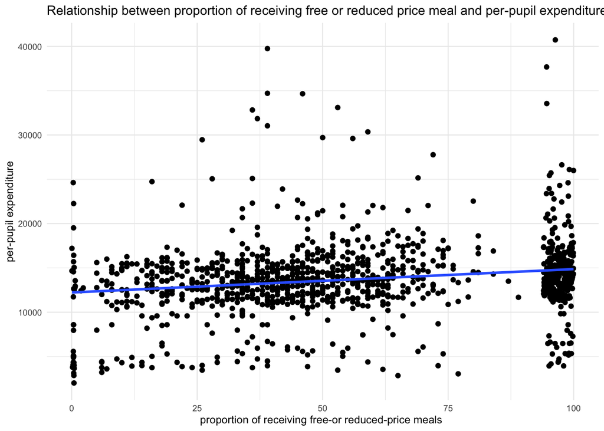

**1.3. Describe the bi-variate relationship using direction, linearity, outliers, strength, and magnitude.**

*The bivariate relationship is slightly positive, non-linear, with a lot of outliers. The relationship strength is weak. the magnitude in the data is relatively shallow.*

### 2.Research Question: Do schools that educate a larger proportion of students with financial need spend more per student on their education?

**2.1. Write a formal linear model that describes the simple, bivariate relationship between school-level per-pupil expenditure and the school-level average receipt of free- or reduced-price lunch and interpret each of the terms in this model. (1 point)**

*ppe = intercept + slope x frpl*

**2.2. State your null hypothesis about the relationship between per-pupil expenditure and the proportion of students receiving free- or reduced-price lunch. (1 point)**

*There is no effect between per-pupil expenditure and the proportion of students receiving free- or reduced-price lunch.*

**2.3. Formally test your hypothesis using an Ordinary Least Squares estimation strategy. Report your results in a formatted table. (2 points)**

```
##
## Call:
## lm(formula = ppe ~ frpl, data = nerds)
##
## Residuals:
##      Min       1Q   Median       3Q      Max
## -11209.7  -1770.4   -119.9   1785.0  26497.3
##
## Coefficients:
##             Estimate Std. Error t value Pr(>|t|)
## (Intercept)  12226.9      258.4  47.322  < 2e-16 ***
## frpl          2634.3      407.2   6.469 1.44e-10 ***
## ---
## Signif. codes:  0 '***' 0.001 '**' 0.01 '*' 0.05 '.' 0.1 ' ' 1
##
## Residual standard error: 4202 on 1191 degrees of freedom
## Multiple R-squared:  0.03394,    Adjusted R-squared:  0.03313
## F-statistic: 41.85 on 1 and 1191 DF,  p-value: 1.438e-10
```

|  | (1) |
| --- | --- |
| (Intercept) | 12226.904 |
|  | (258.379) |
| the proportion of students receiving free- or reduced-price lunch | 2634.332 |
|  | (407.232) |
| Num.Obs. | 1193 |
| R2 | 0.034 |

**2.5 Assess the quality of your model fit using the R^2 statistic. (1 point)**

*The R-squred value is 0.03. This means that our model accounts for 3% of the variance in per-pupil expenditure.*

**2.6. Select an alpha-threshold and describe the corresponding confidence interval for your estimates of the relationship between frpl and ppe. (1 point)**

*I select 0.05 as the alpha threshold for the relationship. Under the null hypothesis, it is extremaly unlikely to obtain a “the proportion of students receiving free- or reduced-price lunch slop” of 2634.3. Therefore, we can reject the null hypothesis and conclude that there is a positive relationship between the proportion of students receiving free- or reduced-price lunch and per-pupil expenditure in the population.*

**2.7. Imagine you are an analyst working for Colt Gill, Director of the Oregon Department of Education. You have been tasked with describing to him whether schools with greater levels of student financial need receive more money. Write a short paragraph reporting the results of your analysis, while introducing appropriate caveats and nuances as needed. In particular, you should think about how you want to introduce the ideas of model fit, omitted variables and correlation for a lay audience. (1 point)**